# Woodland-Chaparral Community Analysis

## Overview

**These analyses explore the composition of plant communities where some woodland and chaparral species often co-occur on the fringes of the Mojave Desert.**

**To discern whether the composition of these assemblages are all pretty much the same, or characteristically somehow different, I set out to use a k-means clustering analysis.**

**To explore how the distribution of chaparral species varies among communities, I generated some elevation maps with chaparral density bubble plots, and then used one of these models to plot some topographic metrics**

## Libraries

```r
#load libraries
library(tidyverse)
library(here)
library(kableExtra)
library(cluster)
library(factoextra)
library(maps)
library(mapdata)
library(mapproj)
library(ggplot2)
library(ggpubr)
library(raster)
library(scales)
library(rgeos)
```

## k-means data preparation

**The data matrix includes the abundance of 21 community dominant species (given as: *Genus species* = “GenSpe”) sampled across 14 transects (T2, T3, etc.).**

```r
df <- read_csv('C:/Users/pfura/Documents/Microclimatic Refugia of Disjunct Chaparral Relicts in Mountains of the Eastern Mojave Desert/K-means clustering/Data/ChaparralKmeans2.csv')
df %>% kbl() %>% kable_classic()
```

| Species | T2 | T3 | T4 | T5 | T6 | T7 | T8 | T9 | T10 | T11 | T12 | T13 | T14 | T15 |
| --- | --- | --- | --- | --- | --- | --- | --- | --- | --- | --- | --- | --- | --- | --- |
| PinMon | 0.380 | 0.2906 | 0.0474 | 0.0000 | 0.0560 | 0.2620 | 0.130 | 0.1120 | 0.0000 | 0.0000 | 0.000 | 0.0000 | 0.0240 | 0.7884 |
| PinEdu | 0.000 | 0.0000 | 0.0360 | 0.0000 | 0.0000 | 0.0000 | 0.000 | 0.0000 | 0.0000 | 0.0000 | 0.000 | 0.0000 | 0.0000 | 0.0000 |
| PinX | 0.000 | 0.0000 | 0.1520 | 0.0000 | 0.0000 | 0.0780 | 0.000 | 0.0000 | 0.0000 | 0.0000 | 0.000 | 0.0000 | 0.0000 | 0.0000 |
| JunOst | 0.000 | 0.2200 | 0.0860 | 0.0000 | 0.3100 | 0.0000 | 0.000 | 0.0000 | 0.0000 | 0.0000 | 0.000 | 0.0000 | 0.0000 | 0.0000 |
| QueCry | 0.332 | 0.3380 | 0.7140 | 0.0880 | 0.0000 | 0.0000 | 0.000 | 0.0000 | 0.0000 | 0.0000 | 0.896 | 0.0000 | 0.0000 | 0.2400 |
| QueTur | 0.195 | 0.1840 | 0.0000 | 0.0480 | 0.0000 | 0.3556 | 0.453 | 0.0000 | 0.0000 | 0.0000 | 0.000 | 0.0000 | 0.0000 | 0.0000 |
| GarFla | 0.028 | 0.1180 | 0.2006 | 0.1300 | 0.0000 | 0.1210 | 0.067 | 0.0000 | 0.0000 | 0.0000 | 0.350 | 0.2880 | 0.3340 | 0.2010 |
| EriAng | 0.178 | 0.0000 | 0.0000 | 0.0000 | 0.1464 | 0.0000 | 0.000 | 0.0000 | 0.0000 | 0.0000 | 0.000 | 0.0000 | 0.0000 | 0.0000 |
| BriCal | 0.000 | 0.0030 | 0.0000 | 0.0278 | 0.0000 | 0.0000 | 0.000 | 0.0000 | 0.0000 | 0.0000 | 0.000 | 0.0750 | 0.0000 | 0.0000 |
| CeaPau | 0.000 | 0.0000 | 0.0710 | 0.0000 | 0.0000 | 0.1384 | 0.000 | 0.1000 | 0.1830 | 0.0910 | 0.000 | 0.0000 | 0.0500 | 0.2270 |
| RhaIli | 0.000 | 0.0000 | 0.0130 | 0.0000 | 0.0000 | 0.0000 | 0.000 | 0.0700 | 0.0510 | 0.0000 | 0.000 | 0.0290 | 0.3350 | 0.0000 |
| FraCal | 0.000 | 0.0000 | 0.0000 | 0.2200 | 0.0000 | 0.0000 | 0.213 | 0.0000 | 0.0000 | 0.1944 | 0.161 | 0.1404 | 0.0380 | 0.0000 |
| RhuAro | 0.000 | 0.0000 | 0.0000 | 0.0000 | 0.1580 | 0.0140 | 0.000 | 0.0000 | 0.0000 | 0.3380 | 0.000 | 0.0000 | 0.0000 | 0.0000 |
| ArcPun | 0.000 | 0.0000 | 0.0000 | 0.0000 | 0.0000 | 0.1800 | 0.000 | 0.0672 | 0.0400 | 0.0000 | 0.000 | 0.0000 | 0.0500 | 0.0000 |
| QueWis | 0.000 | 0.0000 | 0.0000 | 0.0000 | 0.0000 | 0.0000 | 0.000 | 0.3830 | 0.2280 | 0.4190 | 0.000 | 0.0000 | 0.0000 | 0.2400 |
| QueJoh | 0.000 | 0.0000 | 0.0000 | 0.0000 | 0.0000 | 0.0000 | 0.000 | 0.0000 | 0.0000 | 0.0000 | 0.000 | 0.0000 | 0.1090 | 0.0330 |
| CerBet | 0.000 | 0.0000 | 0.0000 | 0.0000 | 0.0000 | 0.0000 | 0.000 | 0.2210 | 0.0310 | 0.0240 | 0.000 | 0.0000 | 0.0500 | 0.1690 |
| EriTri | 0.000 | 0.0000 | 0.0000 | 0.0000 | 0.0000 | 0.0000 | 0.000 | 0.0330 | 0.0016 | 0.0000 | 0.000 | 0.0000 | 0.1216 | 0.0000 |
| HesYuc | 0.000 | 0.0000 | 0.0000 | 0.0000 | 0.0000 | 0.0000 | 0.000 | 0.0840 | 0.1704 | 0.0000 | 0.000 | 0.0440 | 0.1870 | 0.0090 |
| EriFas | 0.000 | 0.0000 | 0.0000 | 0.0000 | 0.0000 | 0.0000 | 0.000 | 0.1566 | 0.0368 | 0.0000 | 0.000 | 0.0000 | 0.0556 | 0.0000 |
| ArcGlan | 0.000 | 0.0000 | 0.0000 | 0.0000 | 0.0000 | 0.0000 | 0.000 | 0.1820 | 0.1100 | 0.0000 | 0.000 | 0.1950 | 0.0780 | 0.0000 |

```r
#need to change the variable format of Species to character
df$Species <- as.character(df$Species)
str(df)

#change column variable as row names
rownames(df) <- c(df$Species)
head(df)

#get rid of non-numeric first column
df2 <- df[,-1]
head(df2)

#final preparation
df2 <- na.omit(df2) #removes NAs #I don't have NAs but this is such a formality...
df2 <- scale(df2) #standardize variables (recommended)
head(df2)
```

## Distance matrix

**k-means clustering is a non-hierarchical clustering algorithm that uses a matrix of variables and objects to assign the association of each to some number of similarity clusters (k).**

**The k-means analysis iteratively assigns the variables to the cluster that minimizes both within and between cluster variance.**

**The Euclidean distance of a matrix can be used to calculate the similarity of species abundance (variables) between transects (objects).**

**Red pairs are dissimilar and teal pairs are similar**

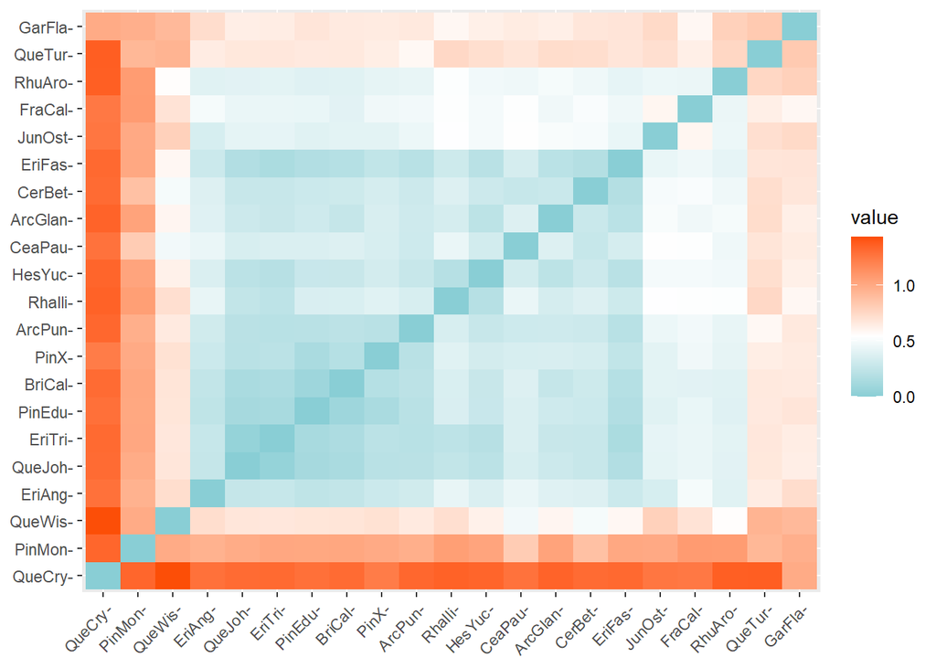

```r
#take a look at the Euclidean distance matrix
distance <- get_dist(df)
fviz_dist(distance, gradient = list(low = "#00AFBB", mid = "white", high = "#FC4E07"))
```

## Look for approriate levels of k

**The average silhouette method is a quantitative technique for identifying the number of clusters that maximizes the variance explained by the model**

**It is used to non-subjectively specify the appropriate level of k.**

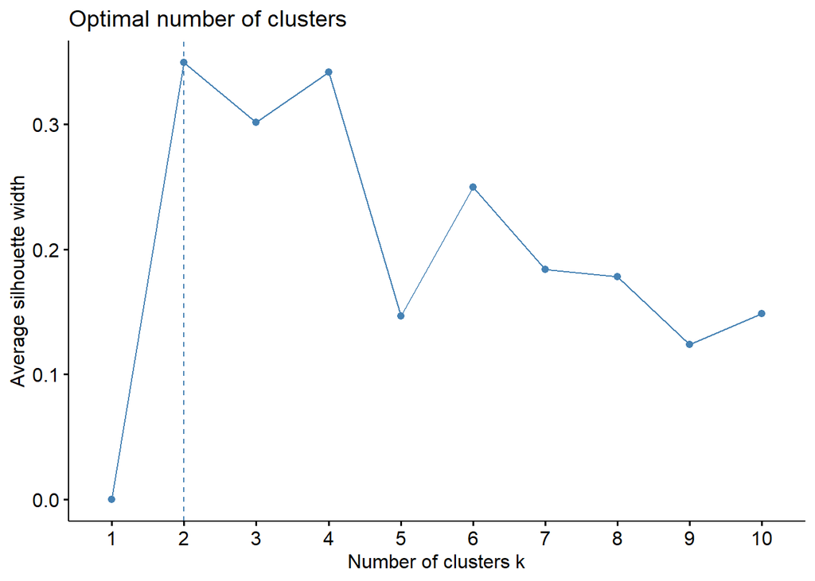

```r
#function to compute average silhouette for k clusters
fviz_nbclust(df2, kmeans, method = "silhouette") #suggests k=2 is best
```

## Clustering analysis with k = 2

**It pretty much looks like there are two clusters with support from the average silhouette method**

```r
#compute k-means clustering with k = 2
set.seed(123)
final <- kmeans(df2, 2, nstart = 25)
print(final)

#build a ggplot onto the fviz_cluster function
fviz_cluster(final, data = df2, repel = TRUE, ellipse = TRUE,show.clust.cent = FALSE, main = FALSE)+
             scale_colour_manual(values = c("dodger blue","red")) +
             scale_fill_manual(values = c("light blue", "orange"))+
             theme_bw()+
             ggsave("kmeans.png")
```

```r
#generate final output with k = 2
final_output<-df %>% ###must use the non-standardized data here
  mutate(Cluster = final$cluster) %>%
  group_by(Cluster) %>%
  summarise_all("mean")
final_output %>% kbl() %>% kable_classic() #shows the k-means values for each cluster by transect
```

| Cluster | Species | T2 | T3 | T4 | T5 | T6 | T7 | T8 | T9 | T10 | T11 | T12 | T13 | T14 | T15 |
| --- | --- | --- | --- | --- | --- | --- | --- | --- | --- | --- | --- | --- | --- | --- | --- |
| 1 | NA | 0.187000 | 0.1861200 | 0.192400 | 0.0972000 | 0.0112 | 0.14772 | 0.1726 | 0.02240 | 0.0000000 | 0.03888 | 0.2814 | 0.0856800 | 0.0792000 | 0.245880 |
| 2 | NA | 0.011125 | 0.0139375 | 0.022375 | 0.0017375 | 0.0384 | 0.02565 | 0.0000 | 0.08105 | 0.0532375 | 0.05450 | 0.0000 | 0.0214375 | 0.0647625 | 0.042375 |

**Higher values indicate which of the two clusters characterize each transect**

## Chaparral density map

**The first map shows the density of chaparral-type plant species and location of sites surveyed in two counties within CA**

**The map data frame has latitude(lat), longitude(long), and the density of chaparral species for each site surveyed**

```r
mapdf<-read_csv(here('Chaparral_Density_Maps/Data/ChaparralDensity.csv'))
density<-mapdf
mapdf %>% kbl() %>% kable_classic
```

| lat | long | density |
| --- | --- | --- |
| 35.26945 | -115.2929 | 0.2145667 |
| 35.26659 | -115.2913 | 0.0878187 |
| 35.26743 | -115.2963 | 0.7047283 |
| 35.27019 | -115.2929 | 0.4881576 |
| 35.27258 | -115.2772 | 0.0892151 |
| 35.24484 | -115.2967 | 0.3591572 |
| 35.24198 | -115.3001 | 0.3097345 |
| 34.29721 | -117.2133 | 0.1176121 |
| 34.29735 | -117.2135 | 0.2067925 |
| 34.31802 | -117.1959 | 0.2471456 |
| 34.38204 | -117.7714 | 0.5914250 |
| 34.38526 | -117.7732 | 0.3664519 |
| 34.39242 | -117.7843 | 0.4023053 |
| 34.39555 | -117.7622 | 0.3469049 |

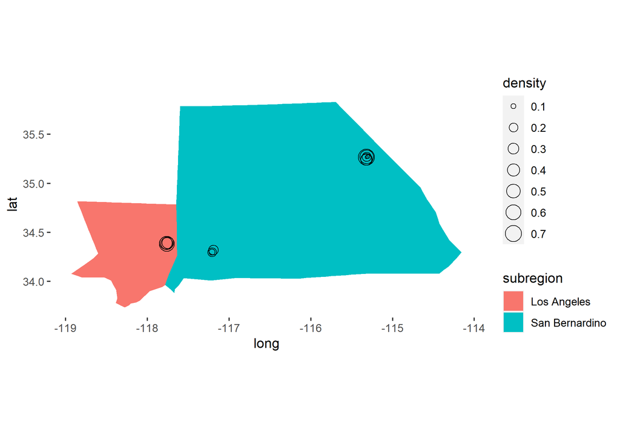

```r
# get data for counties
counties<-map_data("county")
counties<-as.data.frame(counties)
LASB<-counties %>%
  filter(subregion == c("los angeles", "san bernardino"))
  counties[counties$subregion == "los angeles", "subregion"] <- "Los Angeles"
view(LASB)

#make CA map with chaparral density embedded in
p1<-ggplot()+
  geom_polygon(data = LASB,
               aes(x = long,
                   y = lat,
                   group = group,
                  fill = subregion))+
  geom_point(shape=21,data = density,
             aes(x = long,
                 y = lat,
                 size = density))+
  theme(panel.background = element_rect(fill = "white"))+
  scale_fill_discrete(labels = c("Los Angeles", "San Bernardino"))+
  coord_map(projection = "sinusoidal")
  ggsave(here("Chaparral_Density_Maps","Output","ChaparralDensity.png"))
```

## Raster elevation grids

**The second set of maps uses raster elevation data to look closely at chaparral density and the difference in topography among sites**

**This requires generating some digital elevation models (DEM’s) based on data from NASA’s Shuttle Radar Topography Mission (SRTM: https://www2.jpl.nasa.gov/srtm/)**

**The DEM’s can then go into ggplot and be used to make elevation grids along with the chaparral density data**

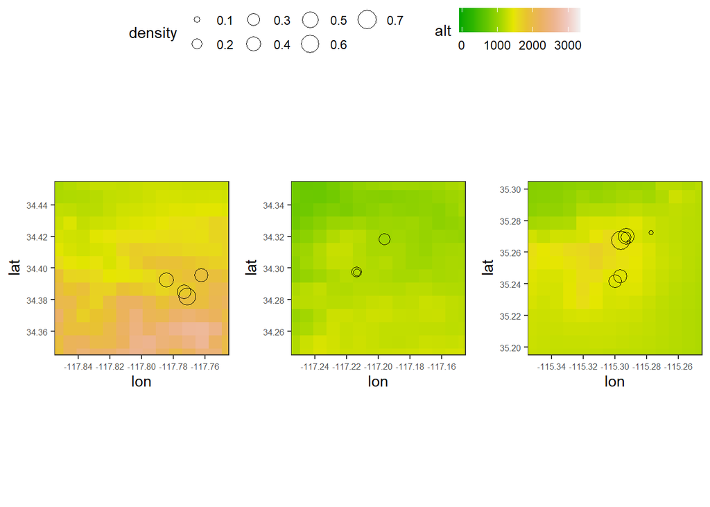

```r
#New York Mnts
#make zoomed in graphs w/ raster layer
#get elevation data
dem1<- getData("SRTM",lat=35.2,lon=-115.35)
dem2<- getData("SRTM",lat=35.3,lon=-115.25)
dem <- merge(dem1,dem2)

#create polygon to crop the elevation data file
Ps1 = as(extent(35.2, 35.3, -115.35, -115.25), 'SpatialPolygons')
crs(Ps1) = "+proj=longlat +datum=WGS84 +no_defs"

#lower the resolution to enable faster plotting
dem_lower_res <- aggregate(dem, fact=10)
dem.p  <-  rasterToPoints(dem_lower_res)
df2 <-  data.frame(dem.p)
colnames(df2) = c("lon", "lat", "alt")

#make ggplot
p2<-ggplot(df2) +
  geom_raster(aes(lon, lat, fill = alt))+
  scale_fill_gradientn(colours = terrain.colors(10))+
  geom_polygon(data= LASB, aes(x=long, y=lat), color= 'blue', fill= NA) +
  coord_sf(xlim = c(-115.35, -115.25), ylim = c(35.2, 35.3))+
  geom_point(shape=21,data = density,
             aes(x = long,
                 y = lat,
                 size = density))+
  theme_bw()+
  theme(axis.text.x = element_text(size=6), axis.text.y = element_text(size=6))

#San Bernardino Mnts
#make zoomed in graphs w/ raster layer
#get elevation data
dem1<- getData("SRTM",lat=34.25,lon=-117.25)
dem2<- getData("SRTM",lat=35.35,lon=-117.15)
dem <- merge(dem1,dem2)

#create polygon to crop the elevation data file
 Ps1 = as(extent(34.25, 34.35, -117.25, -117.15), 'SpatialPolygons')
crs(Ps1) = "+proj=longlat +datum=WGS84 +no_defs"

#lower the resolution to enable faster plotting
dem_lower_res <- aggregate(dem, fact=10)
dem.p  <-  rasterToPoints(dem_lower_res)
df2 <-  data.frame(dem.p)
colnames(df2) = c("lon", "lat", "alt")

#make ggplot
p3<-ggplot(df2) +
  geom_raster(aes(lon, lat, fill = alt))+
  scale_fill_gradientn(colours = terrain.colors(10))+
  geom_polygon(data= LASB, aes(x=long, y=lat), color= 'blue', fill= NA) +
  coord_sf(xlim = c(-117.25, -117.15), ylim = c(34.25, 34.35))+
  geom_point(shape=21,data = density,
             aes(x = long,
                 y = lat,
                 size = density))+
  theme_bw()+
  theme(axis.text.x = element_text(size=6), axis.text.y = element_text(size=6))

#San Gabriel Mnts
#make zoomed in graphs w/ raster layer
#get elevation data
dem1<- getData("SRTM",lat=34.35,lon=-117.85)
dem2<- getData("SRTM",lat=34.45,lon=-117.75)
dem <- merge(dem1,dem2)

#create polygon to crop the elevation data file
Ps1 = as(extent(34.35, 34.45, -117.85, -117.75), 'SpatialPolygons')
crs(Ps1) = "+proj=longlat +datum=WGS84 +no_defs"

#lower the resolution to enable faster plotting
dem_lower_res <- aggregate(dem, fact=10)
dem.p  <-  rasterToPoints(dem_lower_res)
df2 <-  data.frame(dem.p)
colnames(df2) = c("lon", "lat", "alt")

#make ggplot
p4<-ggplot(df2) +
  geom_raster(aes(lon, lat, fill = alt))+
  scale_fill_gradientn(colours = terrain.colors(10))+
  geom_polygon(data= LASB, aes(x=long, y=lat), color= 'blue', fill= NA) +
  coord_sf(xlim = c(-117.85, -117.75), ylim = c(34.35, 34.45))+
  geom_point(shape=21,data = density,
             aes(x = long,
                 y = lat,
                 size = density))+
  theme_bw()+
  theme(axis.text.x = element_text(size=6), axis.text.y = element_text(size=6))

#combine all 3 grids together into a single figure
ggarrange(p4, p3, p2,
          ncol = 3, nrow = 1,
          common.legend = TRUE)
```

## Topographic analysis

**Finally, the terrain() function can take a DEM and calculate environmental data such as slope, aspect, and topographic position index (TPI)**

**slope = steepness of terrain, and aspect = direction of exposure, both calculated in radians**

```r
#calculate environmental data for one of the preliminary sites that I surveyed

#need to generate a digital elevation model (DEM)
DEM1 <- getData('SRTM',lat=35.2,lon=-115.35)
DEM2 <- getData('SRTM',lat=35.3,lon=-115.25)
NYMNTS_DEM <- merge(DEM1,DEM2)

#SRTM data comes packaged in 5x5 decimal degree grids, so the site has to be extracted out
#create a bounding box
lon <- c(-115.35, -115.25)
lat <- c(35.2, 35.3)
lon <- c(-115.35, -115.25)
lat <- c(35.2, 35.3)
bbox <- matrix(c(lon[1], lat[1], lon[2], lat[2]), 2, 2,
               dimnames = list(c("lon", "lat"), c("min", "max")))

#extract the DEM using crop()
NYMNTS_DEM_crop <- crop(x = NYMNTS_DEM, y = bbox)
NYMNTS_DEM_crop
```

```
## class      : RasterLayer
## dimensions : 120, 120, 14400  (nrow, ncol, ncell)
## resolution : 0.0008333333, 0.0008333333  (x, y)
## extent     : -115.35, -115.25, 35.2, 35.3  (xmin, xmax, ymin, ymax)
## crs        : +proj=longlat +datum=WGS84 +no_defs
## source     : memory
## names      : layer
## values     : 1142, 2256  (min, max)
```

```r
#calculate environmental data
env_data <- terrain(NYMNTS_DEM_crop, opt=c("aspect", "slope"), unit="radians", neighbors=8, filename="")
env_data
```

```
## class      : RasterBrick
## dimensions : 120, 120, 14400, 2  (nrow, ncol, ncell, nlayers)
## resolution : 0.0008333333, 0.0008333333  (x, y)
## extent     : -115.35, -115.25, 35.2, 35.3  (xmin, xmax, ymin, ymax)
## crs        : +proj=longlat +datum=WGS84 +no_defs
## source     : memory
## names      :     slope,    aspect
## min values :         0,         0
## max values : 0.7088221, 6.2831853
```

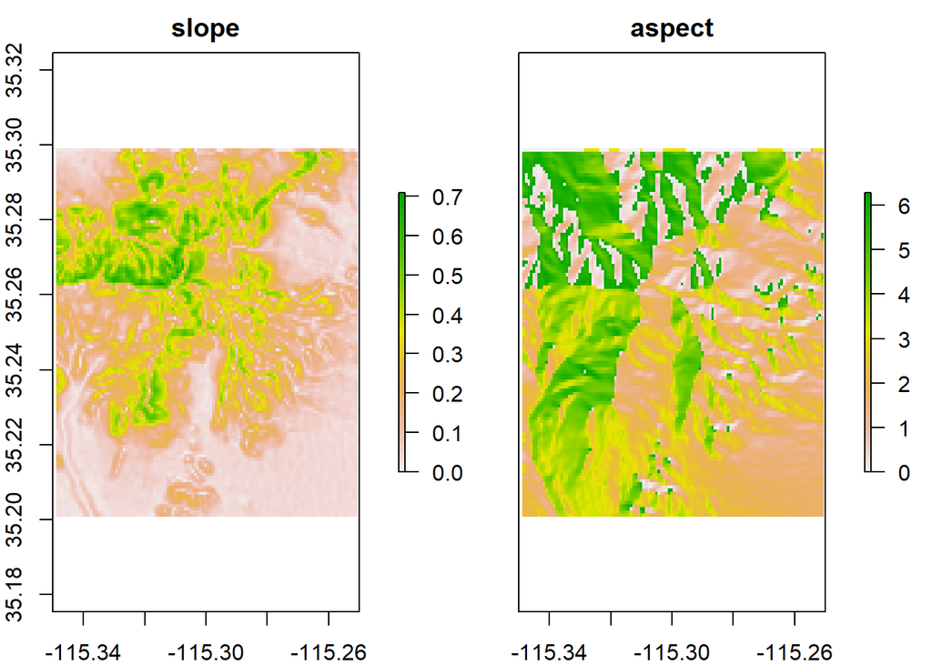

```r
#plot metrics
plot(env_data)
```

```r
#calculate environmental data
env_data <- terrain(NYMNTS_DEM_crop, opt=c("TPI"), unit="radians", neighbors=8, filename="")
env_data
```

```
## class      : RasterLayer
## dimensions : 120, 120, 14400  (nrow, ncol, ncell)
## resolution : 0.0008333333, 0.0008333333  (x, y)
## extent     : -115.35, -115.25, 35.2, 35.3  (xmin, xmax, ymin, ymax)
## crs        : +proj=longlat +datum=WGS84 +no_defs
## source     : memory
## names      : tpi
## values     : -33, 42.5  (min, max)
```

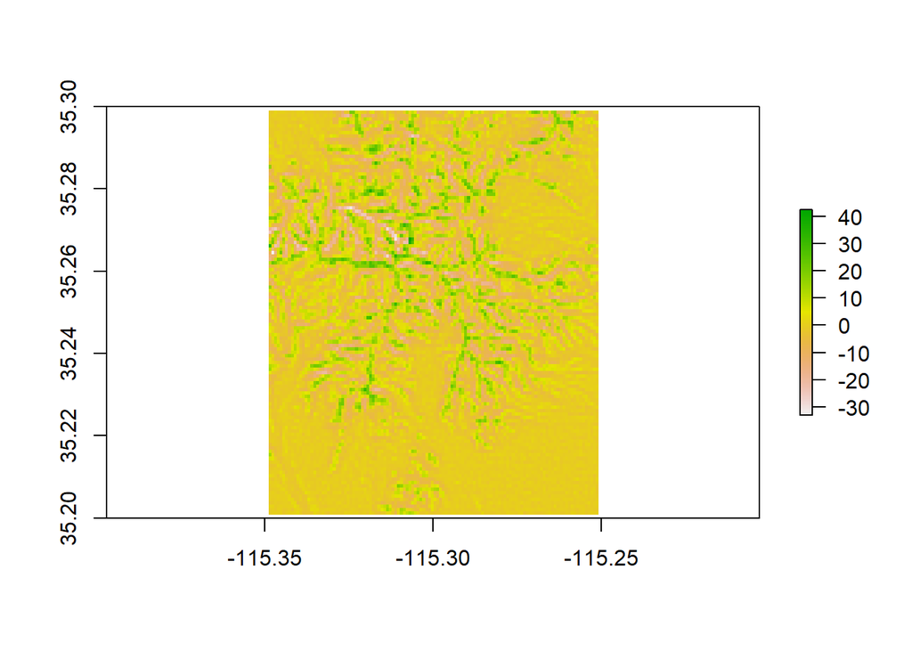

```r
#plot metrics
plot(env_data)
```